# Correlation Stock Market

Jaime Pantoja

```r
library(tidyverse)
library(dplyr)
library(alphavantager)
library(corrplot)
```

## Introduction.

> The purpose of this project is to create a correlation table of 4 stocks using the API of alphavantager (intraday data for stock prices). This table will provide the users with information that will help to make better investment decisions by diversifying risk in different stocks with different levels of correlation.

## Import Intraday Data

> For importing the intraday data we will use the “alphavantager” package. It provides free intraday data, more details can be found here [Cran.r](https://cran.r-project.org/web/packages/alphavantager/alphavantager.pdf) or [R bloggers](https://www.r-bloggers.com/2017/09/alphavantager-an-r-interface-to-the-free-alpha-vantage-financial-data-api/). The syntax is like this:

> av_api_key(“YOUR_API_KEY”)  
> av_get(symbol = “MSFT”, av_fun = “TIME_SERIES_INTRADAY”, interval = “15min”, outputsize = “full”)

## Create a Formula

> Now it is time to create a formula to reduce the repetition of code when pulling data for different stocks. The main idea of the formula is to give the user the capacity to enter the arguments (stock tickers) to get a single table.

> The table will contain the closing prices of each stock and they will be filtered by the time the market is open (9:30 - 4:00). At the end the table will be available as an object in the environment.

```r
intraday_data = function(symbol_1, symbol_2, symbol_3, symbol_4, time)
{

## Here we use the alphavantager package and its functions for each of the 4 stocks to get the intra-day data

av_api_key("3DEJYR8GDCTG7WQK")

table_1 <-av_get(symbol = symbol_1, av_fun = "TIME_SERIES_INTRADAY", interval = time, outputsize = "full") %>%

  mutate(symbol_1 =  close) %>%

  select(1,7)


table_2 <- av_get(symbol = symbol_2, av_fun = "TIME_SERIES_INTRADAY", interval = time, outputsize = "full") %>%

  mutate(symbol_2 =  close) %>%

  select(1, 7)

table_3 <-av_get(symbol = symbol_3, av_fun = "TIME_SERIES_INTRADAY", interval = time, outputsize = "full") %>%

  mutate(symbol_3 =  close) %>%

  select(1,7)

table_4 <-av_get(symbol = symbol_4, av_fun = "TIME_SERIES_INTRADAY", interval = time, outputsize = "full") %>%

  mutate(symbol_4 =  close) %>%

  select(1,7)

## Here we join the tables, we use the left join function

mix_1 <- left_join(table_1,table_2, by = "timestamp")
mix_2 <- left_join(mix_1, table_3, by = "timestamp")
table_closing_prices <- left_join(mix_2, table_4, by = "timestamp") %>%

## Here we create two variables with the values of the hour and the minute.
## We do this in order to filter the data only for a range of time when the market is open

mutate(hour = format(as.POSIXct(timestamp), format = "%H")) %>%
mutate(minute = format(as.POSIXct(timestamp), format = "%M"))


## We need to convert these two variable to a numeric format so later we can filter the time range

## Filtering the range of times:

##For filtering the prices based on a range of time during the day, the solution was to create a "numeric date".
##This is with the idea of filtering a numeric variable

table_closing_prices$hour = as.numeric(as.character( table_closing_prices$hour))
table_closing_prices$minute = as.numeric(as.character( table_closing_prices$minute))

## Now we create a "numeric time", so the filtering process is easier

table_1.1 <<- table_closing_prices %>%
  mutate(date_num = (hour*100)+minute) %>%

## We filter the date_num within the range 930-1600

filter(date_num >= 930 & date_num <= 1600 ) %>%

## We select only the variables that are going to be needed for the analysis

  select(-c(6,7,8)) %>%

  rename( symbol_1 = "symbol_1")
}
```

## Run the formula

```r
intraday_data("IBM","AMZN", "MSFT", "TSLA", "15min")

table_1.1
```

```
## # A tibble: 752 × 5
##    timestamp           symbol_1 symbol_2 symbol_3 symbol_4
##    <dttm>                 <dbl>    <dbl>    <dbl>    <dbl>
##  1 2023-01-17 09:30:00     145.     98.7     237.     126.
##  2 2023-01-17 09:45:00     145.     97.5     237.     127.
##  3 2023-01-17 10:00:00     145.     97.1     239.     128.
##  4 2023-01-17 10:15:00     145.     97.4     240.     129.
##  5 2023-01-17 10:30:00     145.     97.2     240.     130.
##  6 2023-01-17 10:45:00     145.     96.4     238.     128.
##  7 2023-01-17 11:00:00     144.     96.5     239.     129.
##  8 2023-01-17 11:15:00     144.     96.0     238.     128.
##  9 2023-01-17 11:30:00     144.     96.0     238.     129.
## 10 2023-01-17 11:45:00     144.     96.8     239.     129.
## # … with 742 more rows
```

```r
# Here we chang the names of the columns by the order of the selected stocks

table_1.1 <- table_1.1 %>% rename("IBM" = "symbol_1",
                          "AMZN"="symbol_2",
                          "MSFT"="symbol_3",
                          "TSLA"="symbol_4")
```

## Correlation Table

```r
# To create the correlation Matrix we have to drop the timestamp variable

table_cor <- table_1.1 %>% select(2, 3, 4, 5)

# use = "complete.obs" to tell the correlation to ignore the NA values
cor(table_cor, use = "complete.obs")
```

```
##             IBM       AMZN       MSFT       TSLA
## IBM   1.0000000 -0.1850764 -0.3663963 -0.6943689
## AMZN -0.1850764  1.0000000  0.3766468  0.2826603
## MSFT -0.3663963  0.3766468  1.0000000  0.8742098
## TSLA -0.6943689  0.2826603  0.8742098  1.0000000
```

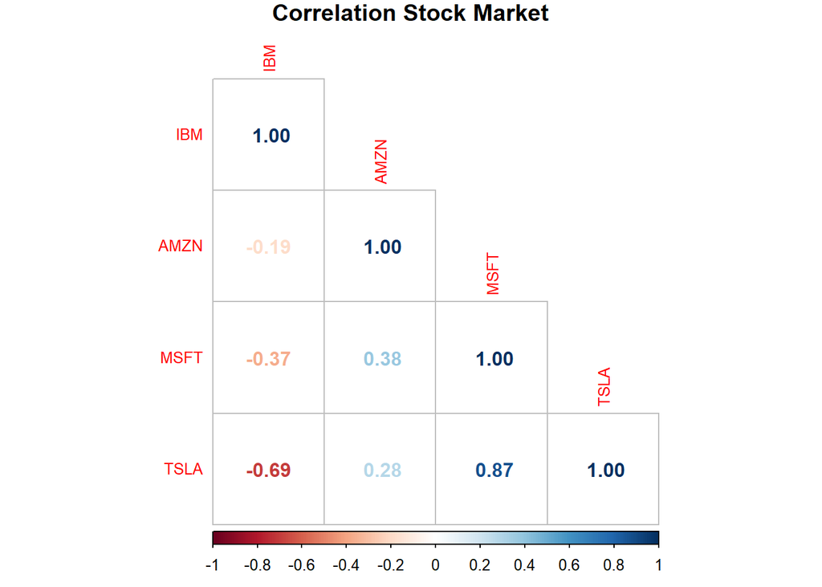

```r
corrplot(cor(table_cor,use = "complete.obs"), method = "number",
         title = "Correlation Stock Market",
         tl.cex = 0.8,
         mar=c(0,0,1,0),
         type="lower")
```